# Analytics Edge HW6

## TODO: Look at all text preceded by ‘NOTE:’

```r
library(magrittr)
library(dplyr)
library(caTools) #for splitting into train/test sets (sample.split)
```

```r
# library(ROCR) #for computing AUCs
# library(rpart) #contains rpart function used to build classification and regression trees
# library(rpart.plot) #contains prp function used to plot classification and regression trees
# library(randomForest) #for building random forest models
library(caret) #for cross-validation
# library(e1071) #for cross-validation
# library(tm)
Sys.setlocale("LC_ALL", "C")
```

```
## [1] "C"
```

## DailyKos

### Problem 1

```r
kos = read.csv('dailykos.csv')
dim(kos)
```

```
## [1] 3430 1545
```

```r
distances = dist(kos, method='euclidean')
kosClust = hclust(distances, method='ward.D')
```

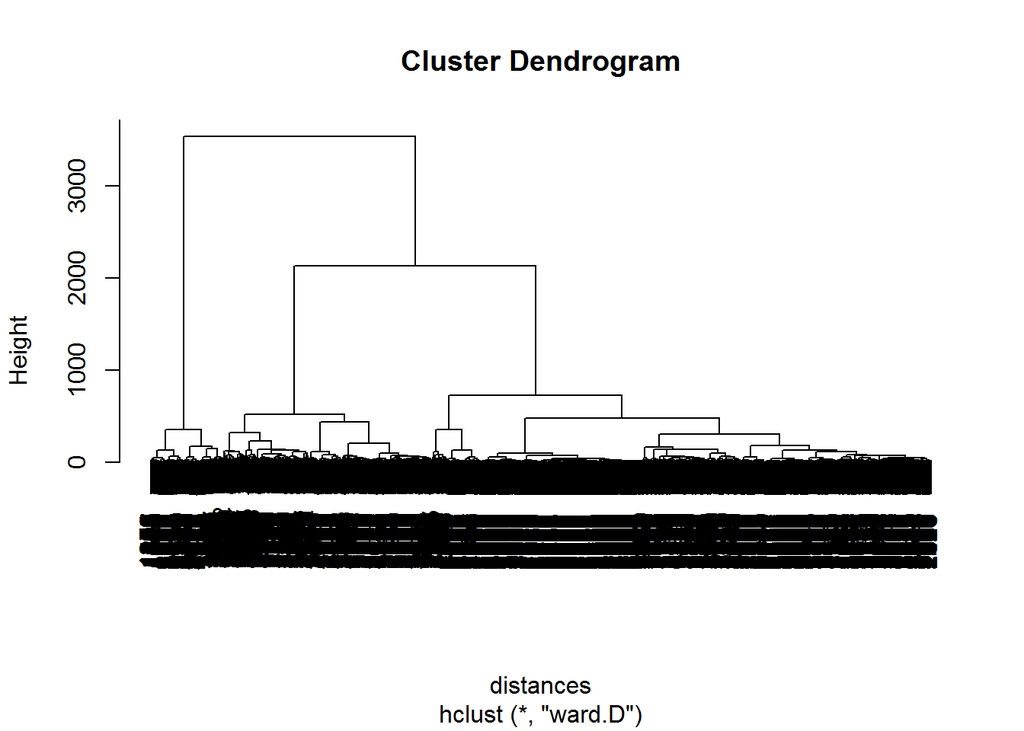

```r
plot(kosClust)
```

From plot generated above, it looks like either 2 or 3 clusters is appropriate due to sufficient vertical spacing btwn horizontal lines.

But we’ll nevertheless use 7 clusters (below)

```r
clustGrps = cutree(kosClust, k = 7) ##calling stats::cutree()
str(clustGrps)
```

```
##  int [1:3430] 1 1 2 3 4 1 5 6 1 6 ...
```

```r
spl = split(kos, clustGrps) #the list elements of spl are each of the 7 clusters
#of the original dataframe, kos.
lapply(spl,nrow)
```

```
## $`1`
## [1] 1266
##
## $`2`
## [1] 321
##
## $`3`
## [1] 374
##
## $`4`
## [1] 139
##
## $`5`
## [1] 407
##
## $`6`
## [1] 714
##
## $`7`
## [1] 209
```

Word in cluster one w/ highest avg frequency (avg’d across all docs)

```r
spl1 = spl[1]%>%as.data.frame
str(spl1)
```

```
## 'data.frame':    1266 obs. of  1545 variables:
##  $ X1.abandon                                 : int  0 0 0 0 0 0 0 0 0 0 ...
##  $ X1.abc                                     : int  0 0 0 0 0 0 0 0 0 0 ...
##  $ X1.ability                                 : int  0 0 0 0 0 0 0 0 0 0 ...
##  $ X1.abortion                                : int  0 0 0 0 0 0 0 0 0 0 ...
##  $ X1.absolute                                : int  0 0 0 0 0 0 0 0 0 0 ...
##  $ X1.abstain                                 : int  0 0 0 0 0 0 0 0 0 0 ...
##  $ X1.abu                                     : int  0 0 0 0 0 0 0 0 0 0 ...
##  $ X1.abuse                                   : int  0 0 0 0 0 0 0 0 0 0 ...
##  $ X1.accept                                  : int  0 0 0 0 0 0 0 0 0 0 ...
##  $ X1.access                                  : int  0 0 0 0 0 0 0 0 0 1 ...
##  $ X1.accomplish                              : int  0 0 0 0 0 0 0 1 1 0 ...
##  $ X1.account                                 : int  0 0 0 0 0 0 0 0 0 0 ...
##  $ X1.accurate                                : int  0 0 0 0 0 0 0 0 0 0 ...
##  $ X1.accusations                             : int  0 0 0 0 0 0 0 0 1 0 ...
```

[output cut: 86 more lines]

```r
names(spl1) = sub('X1.','',names(spl1),fixed=T)
str(spl1)
```

```
## 'data.frame':    1266 obs. of  1545 variables:
##  $ abandon                                 : int  0 0 0 0 0 0 0 0 0 0 ...
##  $ abc                                     : int  0 0 0 0 0 0 0 0 0 0 ...
##  $ ability                                 : int  0 0 0 0 0 0 0 0 0 0 ...
##  $ abortion                                : int  0 0 0 0 0 0 0 0 0 0 ...
##  $ absolute                                : int  0 0 0 0 0 0 0 0 0 0 ...
##  $ abstain                                 : int  0 0 0 0 0 0 0 0 0 0 ...
##  $ abu                                     : int  0 0 0 0 0 0 0 0 0 0 ...
##  $ abuse                                   : int  0 0 0 0 0 0 0 0 0 0 ...
##  $ accept                                  : int  0 0 0 0 0 0 0 0 0 0 ...
##  $ access                                  : int  0 0 0 0 0 0 0 0 0 1 ...
##  $ accomplish                              : int  0 0 0 0 0 0 0 1 1 0 ...
##  $ account                                 : int  0 0 0 0 0 0 0 0 0 0 ...
##  $ accurate                                : int  0 0 0 0 0 0 0 0 0 0 ...
##  $ accusations                             : int  0 0 0 0 0 0 0 0 1 0 ...
```

[output cut: 86 more lines]

```r
spl1%>%colMeans()%>%sort()%>%tail(1)
```

```
##     bush
## 1.705371
```

```r
spl2 = spl[2]%>%as.data.frame
names(spl2) = sub('X2.','',names(spl2),fixed=T)
spl2%>%colMeans()%>%sort(decreasing = T)%>%head(6)
```

```
##  november      poll      vote challenge  democrat      bush
## 10.339564  4.847352  4.398754  4.096573  2.850467  2.847352
```

Checking now to see which cluster is most related to Iraq War and which cluster is most related to the Democratic Party nomination (contains stems of ‘kerry’, ‘dean’ and ‘edwards’ as top words)

```r
lapply(spl, function(x){
  x=x%>%as.data.frame
  names(x)=sub('^.+\\.','',names(x))
  x%>%colMeans()%>%sort(decreasing=T)%>%head(6)
})
```

```
## $`1`
##       bush      kerry   democrat       poll republican      state
##  1.7053712  1.0624013  0.9194313  0.9036335  0.7590837  0.7575039
##
## $`2`
##  november      poll      vote challenge  democrat      bush
## 10.339564  4.847352  4.398754  4.096573  2.850467  2.847352
##
## $`3`
##       bush   democrat republican      state    parties      elect
##   4.406417   3.823529   2.524064   2.320856   1.665775   1.647059
##
## $`4`
##    kerry     bush     poll presided    voter campaign
## 8.438849 7.834532 3.589928 1.625899 1.539568 1.431655
##
## $`5`
##           bush           iraq            war administration       presided
##       3.941032       2.427518       1.776413       1.230958       1.120393
##       american
##       1.090909
##
## $`6`
##      poll  democrat     elect     kerry      bush      race
## 0.5812325 0.5644258 0.5350140 0.5168067 0.4887955 0.4579832
##
## $`7`
##     dean    kerry     poll   edward    clark democrat
## 5.803828 3.952153 2.765550 2.607656 2.497608 2.148325
```

NOTE: Above code slice just prints top words in each cluster. Try to instead print the clusters that contain respectively words related to the Iraq War and words related to Democratic Party nomation (just print the cluster names).

### Problem 2

```r
set.seed(1000)
kmkos = kmeans(kos, centers=7)
table(kmkos$cluster)
```

```
##
##    1    2    3    4    5    6    7
##  146  144  277 2063  163  329  308
```

```r
spl = split(kos, kmkos$cluster)
lapply(spl, function(x){
  colMeans(x)%>%sort(decreasing = T)%>%head(6)
})
```

```
## $`1`
##           bush       presided administration          kerry           iraq
##      11.431507       2.767123       2.664384       1.636986       1.616438
##          state
##       1.609589
##
## $`2`
##      dean     kerry     clark    edward  democrat primaries
##  8.277778  4.979167  3.090278  2.798611  2.694444  2.319444
##
## $`3`
##           iraq            war           bush       american          iraqi
##       4.093863       3.025271       2.610108       1.685921       1.610108
## administration
##       1.389892
##
## $`4`
##       bush   democrat       poll      kerry republican      elect
##  1.1473582  0.7891420  0.7474552  0.6495395  0.6175473  0.6010664
##
## $`5`
##   democrat republican    parties      state     senate       race
##   6.993865   4.638037   3.619632   3.521472   2.650307   2.484663
##
## $`6`
##  november      poll      vote challenge      bush  democrat
## 10.370821  4.872340  4.446809  4.121581  2.960486  2.899696
##
## $`7`
##    kerry     bush     poll campaign    voter presided
## 6.480519 5.970779 2.788961 1.383117 1.334416 1.324675
```

Let’s see which hierarchical cluster best corresponds to kmeans cluster 2. To do so we’ll make a 2-way table of the clusters (w/ kmeans clusters as rows and hierarchical clusters as columns)

```r
table(kmkos$cluster, clustGrps)
```

```
##    clustGrps
##        1    2    3    4    5    6    7
##   1    3    0   85   10   48    0    0
##   2   11    0   10    5    0    2  116
##   3   64    0   42    0  171    0    0
##   4 1045    0   79    0  145  712   82
##   5   32    0  126    1    3    0    1
##   6    0  320    8    0    1    0    0
##   7  111    1   24  123   39    0   10
```

## Market Segmentation with Passenger Air Travel data

### Problem 1

```r
airlines = read.csv('AirlinesCluster.csv')
str(airlines)
```

```
## 'data.frame':    3999 obs. of  7 variables:
##  $ Balance        : int  28143 19244 41354 14776 97752 16420 84914 20856 443003 104860 ...
##  $ QualMiles      : int  0 0 0 0 0 0 0 0 0 0 ...
##  $ BonusMiles     : int  174 215 4123 500 43300 0 27482 5250 1753 28426 ...
##  $ BonusTrans     : int  1 2 4 1 26 0 25 4 43 28 ...
##  $ FlightMiles    : int  0 0 0 0 2077 0 0 250 3850 1150 ...
##  $ FlightTrans    : int  0 0 0 0 4 0 0 1 12 3 ...
##  $ DaysSinceEnroll: int  7000 6968 7034 6952 6935 6942 6994 6938 6948 6931 ...
```

```r
sapply(airlines, mean)%>%sort()%>%head(2)
```

```
## FlightTrans  BonusTrans
##    1.373593   11.601900
```

```r
sapply(airlines,mean)%>%sort()%>%tail(2)
```

```
## BonusMiles    Balance
##   17144.85   73601.33
```

Clearly the vars Balance and BonusMiles are on a vastly larger scale than the vars BonusTrans and FlightTrans. Without normalizing the data, Balance and BonusMiles would dominate the clustering.

Normalization of a data frame can be accomplished by passing the data frame into the preProcess() function (invoking the preProcess function on a dataframe returns a preProcess object tied to that data frame) in the caret package and then passing that preProcess object into the predict function along with the data frame.

```r
preproc=preProcess(airlines) #preproc is a preProcess instance
airlinesNorm = predict(preproc, airlines)
sapply(airlinesNorm, max)%>%sort(decreasing=T)%>%head(1)
```

```
## FlightMiles
##    21.68029
```

```r
sapply(airlinesNorm, min)%>%sort()%>%head(1)
```

```
## DaysSinceEnroll
##       -1.993361
```

### Problem 2

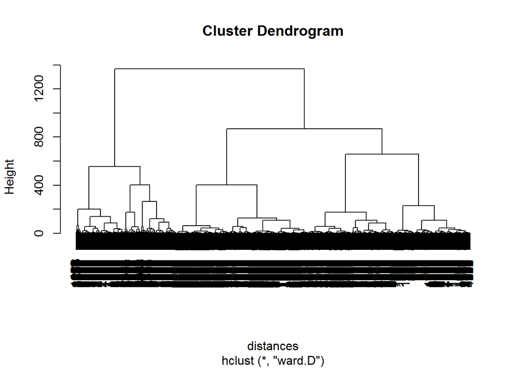

```r
distances = dist(airlinesNorm, method="euclidean")
hclustTree = hclust(distances, method='ward.D')
plot(hclustTree)
```

We’re going with 5 clusters.

```r
airclusters = cutree(hclustTree, k=5)
table(airclusters)[1]
```

```
##   1
## 776
```

Comparing avg values in each var over the 5 clusters…

```r
tapply(airlines$Balance, airclusters, mean)%>%sort(decreasing = T)
```

```
##         3         2         1         4         5
## 198191.57 110669.27  57866.90  52335.91  36255.91
```

```r
tapply(airlines$QualMiles, airclusters, mean)%>%sort(decreasing = T)
```

```
##            2            3            4            5            1
## 1065.9826590   30.3461538    4.8479263    2.5111773    0.6443299
```

```r
tapply(airlines$BonusMiles, airclusters, mean)%>%sort(decreasing = T)
```

```
##         3         2         4         1         5
## 55795.860 22881.763 20788.766 10360.124  2264.788
```

```r
tapply(airlines$BonusTrans, airclusters, mean)%>%sort(decreasing = T)
```

```
##         3         2         4         1         5
## 19.663968 18.229287 17.087558 10.823454  2.973174
```

```r
tapply(airlines$FlightMiles, airclusters, mean)%>%sort(decreasing = T)
```

```
##          2          3          5          4          1
## 2613.41811  327.67611  119.32191  111.57373   83.18428
```

```r
tapply(airlines$FlightTrans, airclusters, mean)%>%sort(decreasing = T)
```

```
##         2         3         5         4         1
## 7.4026975 1.0688259 0.4388972 0.3444700 0.3028351
```

```r
tapply(airlines$DaysSinceEnroll, airclusters, mean)%>%sort(decreasing = T)
```

```
##        1        3        2        5        4
## 6235.365 5615.709 4402.414 3060.081 2840.823
```

```r
# sapply(airlines, tapply(airclusters, mean)) #gives error
```

Faster alternative to calling tapply on each column

```r
lapply(split(airlines,airclusters),colMeans)
```

```
## $`1`
##         Balance       QualMiles      BonusMiles      BonusTrans
##    5.786690e+04    6.443299e-01    1.036012e+04    1.082345e+01
##     FlightMiles     FlightTrans DaysSinceEnroll
##    8.318428e+01    3.028351e-01    6.235365e+03
##
## $`2`
##         Balance       QualMiles      BonusMiles      BonusTrans
##    1.106693e+05    1.065983e+03    2.288176e+04    1.822929e+01
##     FlightMiles     FlightTrans DaysSinceEnroll
##    2.613418e+03    7.402697e+00    4.402414e+03
##
## $`3`
##         Balance       QualMiles      BonusMiles      BonusTrans
##    1.981916e+05    3.034615e+01    5.579586e+04    1.966397e+01
##     FlightMiles     FlightTrans DaysSinceEnroll
##    3.276761e+02    1.068826e+00    5.615709e+03
##
## $`4`
##         Balance       QualMiles      BonusMiles      BonusTrans
##    52335.913594        4.847926    20788.766129       17.087558
##     FlightMiles     FlightTrans DaysSinceEnroll
##      111.573733        0.344470     2840.822581
##
## $`5`
##         Balance       QualMiles      BonusMiles      BonusTrans
##    3.625591e+04    2.511177e+00    2.264788e+03    2.973174e+00
##     FlightMiles     FlightTrans DaysSinceEnroll
##    1.193219e+02    4.388972e-01    3.060081e+03
```

### Problem 3

```r
set.seed(88)
airlinesNormKM = kmeans(airlinesNorm, centers = 5, iter.max=1000)
str(airlinesNormKM)
```

```
## List of 9
##  $ cluster     : int [1:3999] 4 4 4 4 1 4 3 4 2 3 ...
##  $ centers     : num [1:5, 1:7] 1.4444 1.0005 -0.0558 -0.1333 -0.4058 ...
##   ..- attr(*, "dimnames")=List of 2
##   .. ..$ : chr [1:5] "1" "2" "3" "4" ...
##   .. ..$ : chr [1:7] "Balance" "QualMiles" "BonusMiles" "BonusTrans" ...
##  $ totss       : num 27986
##  $ withinss    : num [1:5] 4948 3624 2054 2040 2321
##  $ tot.withinss: num 14987
##  $ betweenss   : num 12999
##  $ size        : int [1:5] 408 141 993 1182 1275
##  $ iter        : int 4
##  $ ifault      : int 0
##  - attr(*, "class")= chr "kmeans"
```

```r
airlinesNormKM$size
```

```
## [1]  408  141  993 1182 1275
```

```r
###same as below, but without cluster headers
airlinesNormKM$cluster%>%table
```

```
## .
##    1    2    3    4    5
##  408  141  993 1182 1275
```

```r
tapply(airlines$Balance, airlinesNormKM$cluster, mean)%>%sort(decreasing = T)
```

```
##         1         2         3         4         5
## 219161.40 174431.51  67977.44  60166.18  32706.67
```

```r
tapply(airlines$QualMiles, airlinesNormKM$cluster, mean)%>%sort(decreasing = T)
```

```
##         2         1         5         4         3
## 673.16312 539.57843 126.46667  55.20812  34.99396
```

```r
tapply(airlines$BonusMiles, airlinesNormKM$cluster, mean)%>%sort(decreasing = T)
```

```
##         1         2         3         4         5
## 62474.483 31985.085 24490.019  8709.712  3097.478
```

```r
tapply(airlines$BonusTrans, airlinesNormKM$cluster, mean)%>%sort(decreasing = T)
```

```
##         2         1         3         4         5
## 28.134752 21.524510 18.429003  8.362098  4.284706
```

```r
tapply(airlines$FlightMiles, airlinesNormKM$cluster, mean)%>%sort(decreasing = T)
```

```
##         2         1         3         4         5
## 5859.2340  623.8725  289.4713  203.2589  181.4698
```

```r
tapply(airlines$FlightTrans, airlinesNormKM$cluster, mean)%>%sort(decreasing = T)
```

```
##          2          1          3          4          5
## 17.0000000  1.9215686  0.8851964  0.6294416  0.5403922
```

```r
tapply(airlines$DaysSinceEnroll, airlinesNormKM$cluster, mean)%>%sort(decreasing = T)
```

```
##        4        1        2        3        5
## 6109.540 5605.051 4684.901 3416.783 2281.055
```

Faster alternative to calling tapply on each column of airlines….

```r
lapply(split(airlines, airlinesNormKM$cluster),colMeans)
```

```
## $`1`
##         Balance       QualMiles      BonusMiles      BonusTrans
##    2.191614e+05    5.395784e+02    6.247448e+04    2.152451e+01
##     FlightMiles     FlightTrans DaysSinceEnroll
##    6.238725e+02    1.921569e+00    5.605051e+03
##
## $`2`
##         Balance       QualMiles      BonusMiles      BonusTrans
##    174431.51064       673.16312     31985.08511        28.13475
##     FlightMiles     FlightTrans DaysSinceEnroll
##      5859.23404        17.00000      4684.90071
##
## $`3`
##         Balance       QualMiles      BonusMiles      BonusTrans
##    6.797744e+04    3.499396e+01    2.449002e+04    1.842900e+01
##     FlightMiles     FlightTrans DaysSinceEnroll
##    2.894713e+02    8.851964e-01    3.416783e+03
##
## $`4`
##         Balance       QualMiles      BonusMiles      BonusTrans
##    6.016618e+04    5.520812e+01    8.709712e+03    8.362098e+00
##     FlightMiles     FlightTrans DaysSinceEnroll
##    2.032589e+02    6.294416e-01    6.109540e+03
##
## $`5`
##         Balance       QualMiles      BonusMiles      BonusTrans
##    3.270667e+04    1.264667e+02    3.097478e+03    4.284706e+00
##     FlightMiles     FlightTrans DaysSinceEnroll
##    1.814698e+02    5.403922e-01    2.281055e+03
```

Let’s now see if the clusters produced by hierarchical clustering line up with those produced by kmeans clustering…

```r
table(airclusters, airlinesNormKM$cluster)
```

```
##
## airclusters    1    2    3    4    5
##           1    4    0   98  673    1
##           2   92  137  105   92   93
##           3  300    4  132   58    0
##           4   12    0  653   30  173
##           5    0    0    5  329 1008
```

Clusters 2 and 5 are pretty close, but the don’t- even somewhat consistently- line up.

## Cluster-then-Predict using NASDAQ stock data

### Problem 1

```r
stocks = read.csv('StocksCluster.csv')
nrow(stocks)
```

```
## [1] 11580
```

```r
mean(stocks$PositiveDec)
```

```
## [1] 0.546114
```

```r
fullCor = cor(stocks[-12])
corNoDiag = fullCor
diag(corNoDiag)=0 #set diagonal elements to 0
corNoDiag
```

```
##              ReturnJan   ReturnFeb    ReturnMar    ReturnApr    ReturnMay
## ReturnJan   0.00000000  0.06677458 -0.090496798 -0.037678006 -0.044411417
## ReturnFeb   0.06677458  0.00000000 -0.155983263 -0.191351924 -0.095520920
## ReturnMar  -0.09049680 -0.15598326  0.000000000  0.009726288 -0.003892789
## ReturnApr  -0.03767801 -0.19135192  0.009726288  0.000000000  0.063822504
## ReturnMay  -0.04441142 -0.09552092 -0.003892789  0.063822504  0.000000000
## ReturnJune  0.09223831  0.16999448 -0.085905486 -0.011027752 -0.021074539
## ReturnJuly -0.08142976 -0.06177851  0.003374160  0.080631932  0.090850264
## ReturnAug  -0.02279202  0.13155979 -0.022005400 -0.051756051 -0.033125658
## ReturnSep  -0.02643715  0.04350177  0.076518327 -0.028920972  0.021962862
## ReturnOct   0.14297723 -0.08732427 -0.011923758  0.048540025  0.017166728
## ReturnNov   0.06763233 -0.15465828  0.037323535  0.031761837  0.048046590
##             ReturnJune    ReturnJuly     ReturnAug     ReturnSep
## ReturnJan   0.09223831 -0.0814297650 -0.0227920187 -0.0264371526
## ReturnFeb   0.16999448 -0.0617785094  0.1315597863  0.0435017706
## ReturnMar  -0.08590549  0.0033741597 -0.0220053995  0.0765183267
## ReturnApr  -0.01102775  0.0806319317 -0.0517560510 -0.0289209718
## ReturnMay  -0.02107454  0.0908502642 -0.0331256580  0.0219628623
## ReturnJune  0.00000000 -0.0291525996  0.0107105260  0.0447472692
## ReturnJuly -0.02915260  0.0000000000  0.0007137558  0.0689478037
## ReturnAug   0.01071053  0.0007137558  0.0000000000  0.0007407139
## ReturnSep   0.04474727  0.0689478037  0.0007407139  0.0000000000
## ReturnOct  -0.02263599 -0.0547089088 -0.0755945614 -0.0580792362
## ReturnNov  -0.06527054 -0.0483738369 -0.1164890345 -0.0197197998
##              ReturnOct   ReturnNov
## ReturnJan   0.14297723  0.06763233
## ReturnFeb  -0.08732427 -0.15465828
## ReturnMar  -0.01192376  0.03732353
## ReturnApr   0.04854003  0.03176184
## ReturnMay   0.01716673  0.04804659
## ReturnJune -0.02263599 -0.06527054
## ReturnJuly -0.05470891 -0.04837384
## ReturnAug  -0.07559456 -0.11648903
## ReturnSep  -0.05807924 -0.01971980
## ReturnOct   0.00000000  0.19167279
## ReturnNov   0.19167279  0.00000000
```

```r
max(corNoDiag)
```

```
## [1] 0.1916728
```

```r
which.max(corNoDiag) #returns linear index (go first down column and to the next row) of max element in matrix corNoDiag
```

```
## [1] 110
```

```r
meanReturns = sapply(stocks[-12], mean)
which.max(meanReturns)
```

```
## ReturnApr
##         4
```

```r
which.min(meanReturns)
```

```
## ReturnSep
##         9
```

## Problem 2 (Logistic Regression without clustering beforehand)

```r
set.seed(144)
spl = sample.split(stocks$PositiveDec, SplitRatio = 0.7)
stocksTrain = subset(stocks, spl)
stocksTest = subset(stocks,!spl)
```

```r
logRegrMod = glm(PositiveDec~., data=stocksTrain, family="binomial")
logRegrPreds = predict(logRegrMod, type='response')
str(logRegrPreds)
```

```
##  Named num [1:8106] 0.633 0.38 0.543 0.649 0.599 ...
##  - attr(*, "names")= chr [1:8106] "1" "2" "4" "6" ...
```

```r
table(stocksTrain$PositiveDec, logRegrPreds>=0.5)
```

```
##
##     FALSE TRUE
##   0   990 2689
##   1   787 3640
```

```r
logRegrPreds = predict(logRegrMod, newdata=stocksTest, type='response')
table(stocksTest$PositiveDec, logRegrPreds>=0.5)
```

```
##
##     FALSE TRUE
##   0   417 1160
##   1   344 1553
```

```r
table(stocksTrain$PositiveDec)
```

```
##
##    0    1
## 3679 4427
```

```r
mean(stocksTest$PositiveDec)
```

```
## [1] 0.5460564
```

### Problem 3 (cluster then predict)

#### Remove Response vars from training and test sets

```r
limitedTrain = stocksTrain
str(limitedTrain)
```

```
## 'data.frame':    8106 obs. of  12 variables:
##  $ ReturnJan  : num  0.08068 -0.01068 -0.07404 0.5798 -0.00604 ...
##  $ ReturnFeb  : num  0.0663 0.1021 -0.0482 0.3323 0.0243 ...
##  $ ReturnMar  : num  0.0329 0.1455 0.0182 -0.4055 0.0189 ...
##  $ ReturnApr  : num  0.1831 -0.0844 -0.0247 -0.06 -0.0128 ...
##  $ ReturnMay  : num  0.13033 -0.3273 -0.00604 0.06073 0.08149 ...
##  $ ReturnJune : num  -0.0176 -0.3593 -0.0253 -0.2154 0.1051 ...
##  $ ReturnJuly : num  -0.0205 -0.0253 -0.094 0.2744 0.026 ...
##  $ ReturnAug  : num  0.0247 0.2113 0.0953 0.5383 -0.0335 ...
##  $ ReturnSep  : num  -0.0204 -0.58 0.0567 0.1271 0.0686 ...
##  $ ReturnOct  : num  -0.1733 -0.2671 -0.0963 -0.1714 0.0118 ...
##  $ ReturnNov  : num  -0.0254 -0.1512 -0.0405 -0.1954 -0.1159 ...
##  $ PositiveDec: int  0 0 1 1 1 0 0 0 1 0 ...
```

```r
limitedTrain$PositiveDec = NULL
str(limitedTrain)
```

```
## 'data.frame':    8106 obs. of  11 variables:
##  $ ReturnJan : num  0.08068 -0.01068 -0.07404 0.5798 -0.00604 ...
##  $ ReturnFeb : num  0.0663 0.1021 -0.0482 0.3323 0.0243 ...
##  $ ReturnMar : num  0.0329 0.1455 0.0182 -0.4055 0.0189 ...
##  $ ReturnApr : num  0.1831 -0.0844 -0.0247 -0.06 -0.0128 ...
##  $ ReturnMay : num  0.13033 -0.3273 -0.00604 0.06073 0.08149 ...
##  $ ReturnJune: num  -0.0176 -0.3593 -0.0253 -0.2154 0.1051 ...
##  $ ReturnJuly: num  -0.0205 -0.0253 -0.094 0.2744 0.026 ...
##  $ ReturnAug : num  0.0247 0.2113 0.0953 0.5383 -0.0335 ...
##  $ ReturnSep : num  -0.0204 -0.58 0.0567 0.1271 0.0686 ...
##  $ ReturnOct : num  -0.1733 -0.2671 -0.0963 -0.1714 0.0118 ...
##  $ ReturnNov : num  -0.0254 -0.1512 -0.0405 -0.1954 -0.1159 ...
```

```r
limitedTest = stocksTest
limitedTest$PositiveDec = NULL
```

#### Normalize training and test sets

Note: when we have training and test sets, **we’ll want to normalize by the mean and standard deviation of the training set** and use the preProcess object returned by calling preProcess on the training set to normalize **both the training and test sets**

```r
preProc = preProcess(limitedTrain)
normTrain = predict(preProc, limitedTrain)
normTest = predict(preProc, limitedTest)
```

```r
set.seed(144)
km = kmeans(normTrain, centers = 3)
km$size
```

```
## [1] 3157 4696  253
```

When using a kmeans clustering model to just cluster a training set, you can just access the ‘cluster’ vector from the kmeans object as `km$cluster`.

If, instead, you’re using a kmeans clustering model to cluster a test dataset (i.e. a dataset aside from that used to built the clustering model), you’ll have to form a flexclust object using the `flexclust::as.kcca()` function, passing in the kmeans model as the first parameter and the training dataset as the second parameter. And then you’ll have to then call the `predict()` function passing in the flexcust object as the first parameter and the test dataset as the second parameter. Note that the cluster vector for the training dataset can also be accessed via the `flexclust::as.kcca()` -> `predict()` idiom, with the only difference being that the predict function wouldn’t take a second parameter in this case.

NOTE: code chunks below here run fine (if previous code chunks in rmd have been run), however, code below here fails to knit (on my laptop).

```r
# kmkcca = flexclust::as.kcca(km, normTrain)
# clusterTrain = predict(flexclust::as.kcca(km, normTrain))
# clusterTest = predict(flexclust::as.kcca(km, normTrain), newdata=normTest)
# table(clusterTrain)
# km$size
```

```r
# table(clusterTest)
```

### Problem 4

```r
# stocksTrain1 = subset(stocksTrain, clusterTrain==1)
# stocksTrain2 = subset(stocksTrain, clusterTrain==2)
# stocksTrain3 = subset(stocksTrain, clusterTrain==3)
# stocksTest1 = subset(stocksTest, clusterTest==1)
# stocksTest2 = subset(stocksTest, clusterTest==2)
# stocksTest3 = subset(stocksTest, clusterTest==3)
# stocksTrain1$PositiveDec%>%mean()
# stocksTrain2$PositiveDec%>%mean()
# stocksTrain3$PositiveDec%>%mean()
```

#### Building logistic regression models for each cluster and checking which variables (months) in the model differ in sign between the models

```r
# StocksModel1 = glm(PositiveDec~., data=stocksTrain1, family="binomial")
# StocksModel2 = glm(PositiveDec~., data=stocksTrain2, family="binomial")
# StocksModel3 = glm(PositiveDec~., data=stocksTrain3, family="binomial")
# summary(StocksModel1)
# summary(StocksModel2)
# summary(StocksModel3)
```

#### Making test set predictions using the 3 models above

```r
# PredictTest1 = predict(StocksModel1, newdata=stocksTest1, type="response")
# PredictTest2 = predict(StocksModel2, newdata=stocksTest2, type="response")
# PredictTest3 = predict(StocksModel3, newdata=stocksTest3, type="response")
# table(stocksTest1$PositiveDec, PredictTest1>=0.5)
# table(stocksTest2$PositiveDec, PredictTest2>=0.5)
# table(stocksTest3$PositiveDec, PredictTest3>=0.5)
```

```r
# AllPredictions = c(PredictTest1, PredictTest2, PredictTest3)
# AllOutcomes = c(stocksTest1$PositiveDec, stocksTest2$PositiveDec, stocksTest3$PositiveDec)
# table(AllOutcomes, AllPredictions>=0.5)
```